# ISSS608 Project Proposal (Team 12)

A proposal outlining our team’s approach to looking at e-commerce data from Olist, a Brazillian e-commerce marketplace integrator, using visual analytics techniques acquired as part of the ISSS608 Visual Analytics course curriculum.

Amber Liu, Jieyuan Zhang, Mei Lin Kwong https://scis.smu.edu.sg/master-it-business (MITB (Analytics))https://scis.smu.edu.sg/  
2022-03-06

# 1.0 Introduction / Motivation for the Project

Brazil is currently the largest ecommerce market in Latin America and the 13th largest in the world despite a low internet penetration of 61% suggesting huge potential for growth in the e-commerce landscape.

In 2019, local e-commerce giant Shopee, launched their app in Brazil’s e-tail market, and has become the most downloaded shopping app in Brazil.

Through the use of the [Olist dataset which comprises data from 2016-2018 made at multiple Olist Store marketplaces in Brazil](https://www.kaggle.com/olistbr/brazilian-ecommerce), our group aims to:

1. Learn about the E-commerce market/consumers preferences/purchase trends of the Brazilian market
2. Discover Olist’s potential areas of growth and improvement
3. Apply visualisation/analytics techniques to deliver the information

# 2.0 Problems or issues that the project will address

[figure not shown]

Olist is a Brazilian e-commerce company which aims to be the largest online shopping platform in the Brazilian market. With a large number of products and sales, a clear visualisation and understanding of the sales and trends of different products and customers are extremely important for future growth.

Besides acting as a platform for product sales, it also does advertisement of products. Hence, the need of understanding different product segments will be critical for their business.

Questions that will be answered in this analysis include:

1. What is the general business trend using data relating to customer activity,, order value and number of orders?
2. What does the data tell us about the potential for sales uplift in the future?

# 3.0 Relevant related work

Given the strong competition that the e-commerce industry faces, market players often employ data-driven strategies to explore and solve business problems for profit maximisation.

In another study done by [Steven et. al (2011)](https://papers.ssrn.com/sol3/papers.cfm?abstract_id=1940960) on historical data for US e-commerce sales obtained from US Censes Bureau, an Autoregressive-moving average (ARIMA) model alongside the Holts-Winters technique was used to predict e-commerce sales from 2011 to 2013; final results show that the e-commerce sales in US were expected to rise rapidly over the course of the 3 year prediction period.

# 4.0 Analysis Approach

Our team aims to analyse the activity and performance of Olist through the following metrics:

1. **Gross Merchandise Value (GMV)** - derived from the sum of value of purchases made in a given observation window
2. **Number of orders**
3. **Number of customers**

The table below summarizes the key plots and visualisation techniques proposed:

[output not shown]

## 4.1 Dataset

The dataset was obtained from Kaggle (**Brazillian E-Commerce Public Dataset by Olist**) accessed through this [link](https://www.kaggle.com/olistbr/brazilian-ecommerce). The dataset has information of 100k orders from 2016 to 2018 made at multiple marketplaces in Brazil.

For the current project scope, we will be using the following datasets provided and transforming it accordingly to suit our use case.

The table below illustrates the specific datasets which will be used:

| S/N | Name | Description |
| --- | --- | --- |
| 1 | *olist_oder_customer_dataset.csv* | Customer level data |
| 2 | *olist_orders_dataset.csv* | Order information |
| 3 | *olist_order_payments_dataset.csv* | Order value |
| 4 | *olist_order_items_dataset.csv* | Information on the exact type of items in each order |
| 5 | *olist_products_dataset.csv* | Map categories to each product |

## 4.2 Proposed packages to be used

- **ggplot2()**: to create data visualisations such as barplots etc.
- **plotly()**: to create interactive web-based graphs
- **readr()**: to get rectangular data out of comma separated (csv)
- **sf()**: import geospatial data into R
- **dplyr()** and **tidyr()**: for data wrangling
- **tmap()**: to create chloropleth maps
- **geobr()**: to download official spatial data sets of Brazil

## 4.3 Project Timeline

| Stage | Task | By (Date) | Members |
| --- | --- | --- | --- |
| 1 | Data Preparation / Wrangling | 14 March | JY/ML |
| 2 | Exploratory Data Analysis | 20 March | A/JY/ML |
| 3 | ARIMA Modelling + Geospatial Analysis + R Shiny App | 20 March | A/JY/ML |
| 4 | Fine-tuning and Start Write-up on Netlify | 22 March | A/JY/ML |
| 5 | Write Up/ Poster / User Guide Draft | 27 March | A/JY/ML |
| 6 | Project Submission Finalisation (Poster/Application/ User Guide) | 2 April | A/JY/ML |

# 5.0 Early Prototypes

Our team has come up with an initial wireframe/protype of the Shiny app which is broken down into 3 sections (Overview, Geospatial Analysis, Sales Analysis) to provide the user with a holistic understanding of the performance and trends in terms of customer behaviour, sales and orders. The images below illustrated in greater detail what we hope to create in the final application.

**1) Overview**

- **Overall (an overview of Olist’s performance filtered by time-period)**

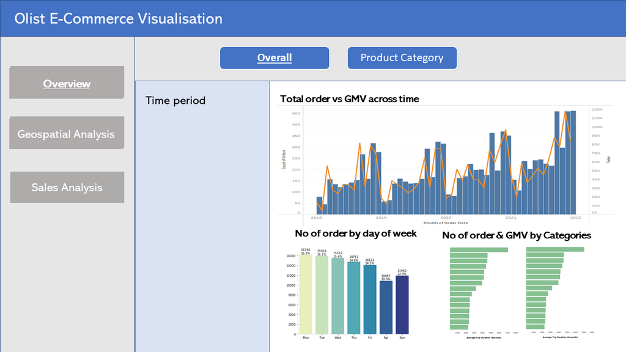

  Overall Tab: Overall

  - Features total order and GMV across time
  - Features number of order by day of the week to give a sense of the activity within a week
  - Number of order and GMV by categories
- **Product Category (the same view as the Overall tab - with the option to be filtered by product category)**

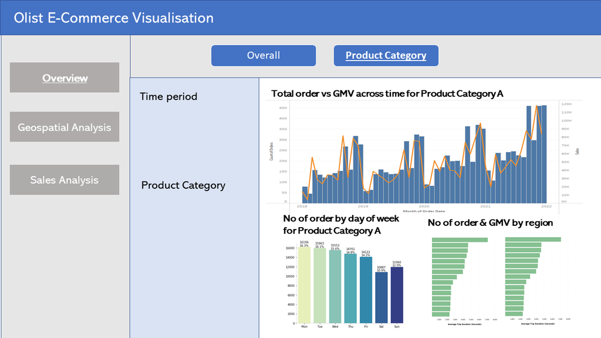

  Overall Tab: Product_category

  - Features total order and GMV across time (for a selected product category)
  - Features number of order by day of the week to give a sense of the activity within a week (for a selected product category)
  - Number of order and GMV by *region*

**2) Geospatial Analysis**

- **Geospatial Analysis**

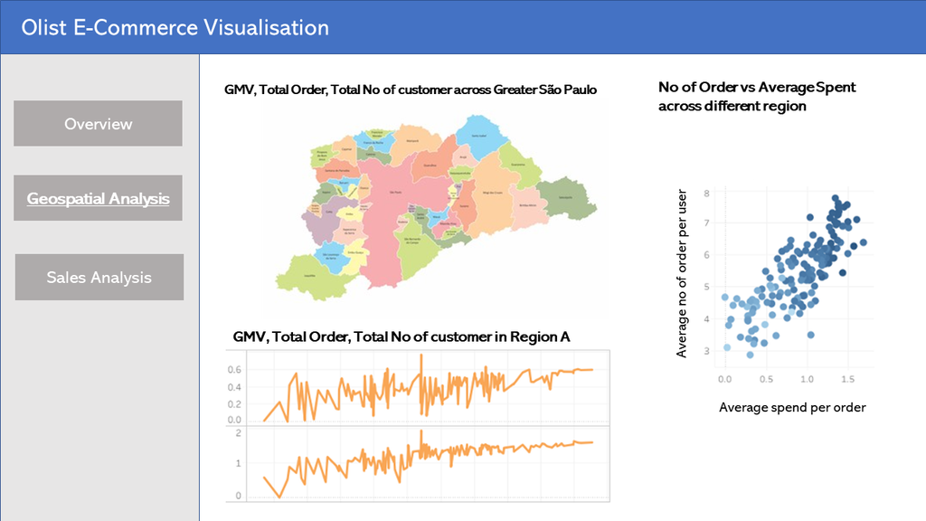

  Geospatial Analysis Tab: Geospatial Analysis

  - Features GMV, Total Order, Total No of customer across Greater Sao Paolo
  - Features GMV, Total Order, Total No of a customer in Region A (based on interactive selection on the map)
  - Feature no. of Order vs Average spent across the different region (scatterplot)

**3) Sales Analysis**

- **Heatmap**

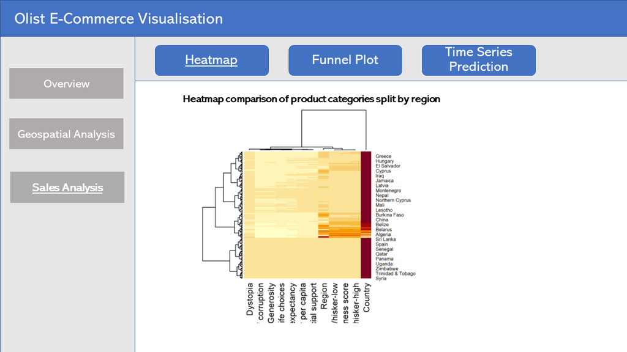

  Sales Analysis Tab: Heatmap

  - Features a heatmap comparison of product categories split by region (as well as a hierarchical clustering to identify patterns)
- **Funnel Plot**

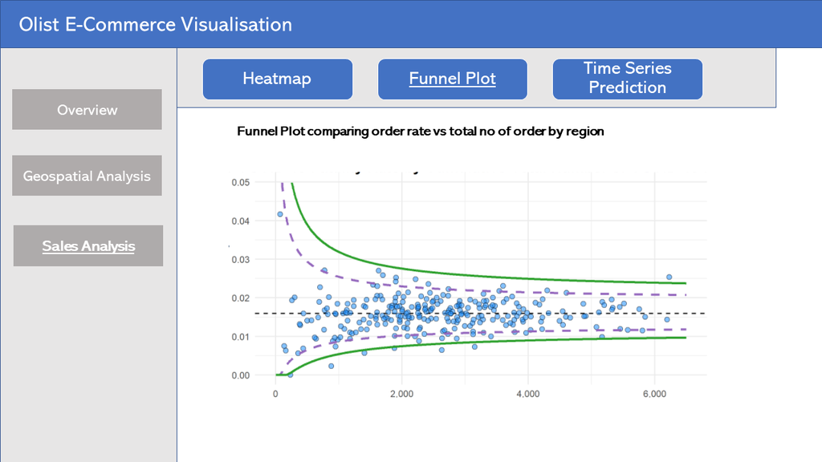

  Sales Analysis Tab: Funnel Plot

  - Features a funnel plot comparing order rate vs total no of order by region
- **Time Series Prediction (ARIMA)**

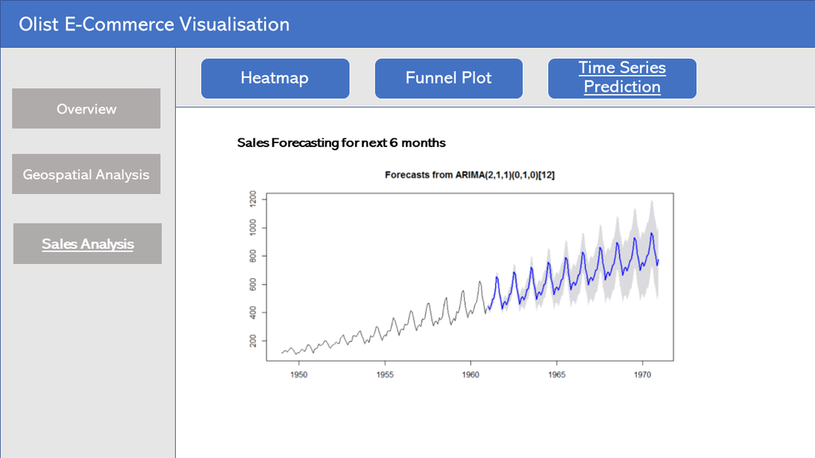

  Sales Analysis Tab: Time Series Analysis using ARIMA

  - Features 6 month forecasting using ARIMA time-series to predict sales/customer/order uplift

# 6.0 References

- [ISSS608 Coursework Curriculum Material](https://isss608-ay2021-22t2.netlify.app/)
- [Olist Dataset from Kaggle](https://www.kaggle.com/olistbr/brazilian-ecommerce)
- [Download Official Spatial Data Sets of Brazil using geobr()](https://github.com/ipeaGIT/geobr#readme)
- [Market Segmentation Analysis and Visualisation Using K-Mode Clustering Algorithm for E-Commerce Business](https://hrcak.srce.hr/en/file/300229)
- [A Time-Series Analysis of U.S. E-Commerce Sales](https://papers.ssrn.com/sol3/papers.cfm?abstract_id=1940960)
- **Arima Modelling**
  - [Arima Modelling](https://rpubs.com/riazakhan94/arima_with_example)
  - [Time Series Forecasting Shiny App Example by aneesha](https://github.com/aneesha/ShinyTimeseriesForecasting)